# Daxing Gao project2:Basic inferential data analysis for tooth growth data

## Overview

The goal is to analyze the ToothGrowth data in the R datasets package. And see if supplements and their doses affect teeth growth.

## Load the ToothGrowth data and analysis

```r
library(ggplot2)
data("ToothGrowth")
```

## Summary of the data

Use summary function on Toothgrowth data. And subset the data by supplement and dose. Plot the data by ggplot to show the teeth length with treatment of different supplements.

```r
summary(ToothGrowth)
```

```
##       len        supp         dose
##  Min.   : 4.20   OJ:30   Min.   :0.500
##  1st Qu.:13.07   VC:30   1st Qu.:0.500
##  Median :19.25           Median :1.000
##  Mean   :18.81           Mean   :1.167
##  3rd Qu.:25.27           3rd Qu.:2.000
##  Max.   :33.90           Max.   :2.000
```

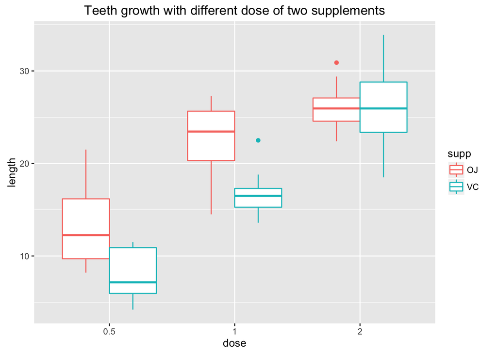

```r
OJ0.5<-subset(ToothGrowth,supp=="OJ"&dose==0.5)
OJ1<-subset(ToothGrowth,supp=="OJ"&dose==1)
OJ2<-subset(ToothGrowth,supp=="OJ"&dose==2)
VC0.5<-subset(ToothGrowth,supp=="VC"&dose==0.5)
VC1<-subset(ToothGrowth,supp=="VC"&dose==1)
VC2<-subset(ToothGrowth,supp=="VC"&dose==2)
ggplot(ToothGrowth,aes(as.character(dose),len,color=supp))+geom_boxplot(aes(group=interaction(supp,dose)))+ggtitle("Teeth growth with different dose of two supplements")+xlab("dose")+ylab("length")
```

## Compare tooth growth by supplements

Calculate the confidence intervals and p-values when comparing two supplements under different dose

```r
dose0.5_VCvsOJ<-c(t.test(VC0.5$len,OJ0.5$len)$conf,t.test(VC0.5$len,OJ0.5$len)$p.value)
dose1_VCvsOJ<-c(t.test(VC1$len,OJ1$len)$conf,t.test(VC1$len,OJ1$len)$p.value)
dose2_VCvsOJ<-c(t.test(VC2$len,OJ2$len)$conf,t.test(VC2$len,OJ2$len)$p.value)
suppl<-rbind(dose0.5_VCvsOJ,dose1_VCvsOJ)
suppl<-rbind(suppl,dose2_VCvsOJ)
suppl<-as.data.frame(suppl)
names(suppl)<-c("lower_conf_interv","higher_conf_interv","p-value")
suppl
```

```
##                lower_conf_interv higher_conf_interv     p-value
## dose0.5_VCvsOJ         -8.780943          -1.719057 0.006358607
## dose1_VCvsOJ           -9.057852          -2.802148 0.001038376
## dose2_VCvsOJ           -3.638070           3.798070 0.963851589
```

## Compare tooth growth by OJ dose

Calculate the confidence intervals and p-values when comparing different dose of OJ

```r
OJdose0.5vs1<-c(t.test(OJ0.5$len,OJ1$len)$conf, t.test(OJ0.5$len,OJ1$len)$p.value)
OJdose1vs2<-c(t.test(OJ1$len,OJ2$len)$conf, t.test(OJ1$len,OJ2$len)$p.value)
OJdose<-rbind(OJdose0.5vs1,OJdose1vs2)
OJdose<-as.data.frame(OJdose)
names(OJdose)<-c("lower_conf_interv","higher_conf_interv","p-value")
OJdose
```

```
##              lower_conf_interv higher_conf_interv      p-value
## OJdose0.5vs1        -13.415634         -5.5243656 8.784919e-05
## OJdose1vs2           -6.531443         -0.1885575 3.919514e-02
```

## Compare tooth growth by VC dose

Calculate the confidence intervals and p-values when comparing different dose of VC

```r
VCdose0.5vs1<-c(t.test(VC0.5$len,VC1$len)$conf, t.test(VC0.5$len,VC1$len)$p.value)
VCdose1vs2<-c(t.test(VC1$len,VC2$len)$conf, t.test(VC1$len,VC2$len)$p.value)
VCdose<-rbind(VCdose0.5vs1,VCdose1vs2)
VCdose<-as.data.frame(VCdose)
names(VCdose)<-c("lower_conf_interv","higher_conf_interv","p-value")
VCdose
```

```
##              lower_conf_interv higher_conf_interv      p-value
## VCdose0.5vs1         -11.26571          -6.314288 6.811018e-07
## VCdose1vs2           -13.05427          -5.685733 9.155603e-05
```

## Conclusions

1.With treatment of OJ, teeth grow longer under 0.5 and 1 dose when compared with VC treated group. But under dose of 2, there is no difference between OJ or VC treated group. 2.With increase of supplement dose, both OJ and VC promote teeth growth. Assumptions to reach the conclusion: samples are representitave of population, doses and supplements are randomly assigned to the samples, the distribution of mean is normal.